# Solution

Facets - Data Visualization - Part 3

### Exercise 1

Read `?facet_wrap`. What does `nrow` do? What does `ncol` do? What other options control the layout of the individual panels? Why doesn’t `facet_grid()` have `nrow` and `ncol` arguments?

To answer these questions try to modify the plots from the notebook by changing the parameters.

**Answer**

The arguments nrow (ncol) determines the number of rows (columns) to use when laying out the facets. It is necessary since facet_wrap() only facets on one variable. These arguments are unnecessary for facet_grid() since the number of rows and columns are determined by the number of unique values of the variables specified.

### Exercise 2

What do the empty cells in plot with `facet_grid(drv ~ cyl)` mean? How do they relate to this plot?

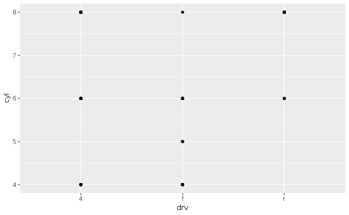

```r
ggplot(data = mpg) +
  geom_point(mapping = aes(x = drv, y = cyl))
```

**Answer**

Empty cells are representing the combinations were we don’t have any observations. These are the same locations in the scatter plot of drv and cyl that have no plots.

### Exercise 3

What plots does the following code make? What does `.` do?

```
ggplot(data = mpg) +
  geom_point(mapping = aes(x = displ, y = hwy)) +
  facet_grid(drv ~ .)

ggplot(data = mpg) +
  geom_point(mapping = aes(x = displ, y = hwy)) +
  facet_grid(. ~ cyl)
```

### Exercise 4

What happens if you facet on a continuous variable?

**Answer**

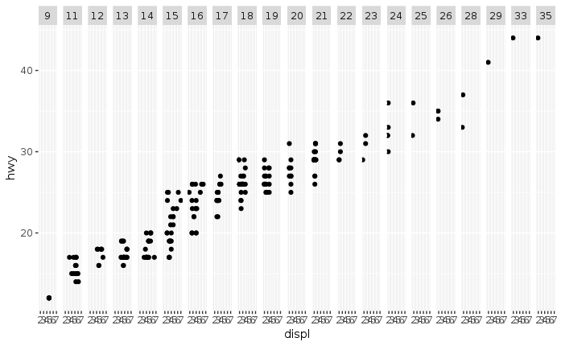

```r
ggplot(mpg, aes(x = displ, y = hwy)) +
  geom_point() +
  facet_grid(. ~ cty)
```

The continuous variable is converted to a categorical variable, and the plot contains a facet for each distinct value.